# Part II - (Influence of Loan Variables on Loan Amount)

## by (Ikuku Success Owhorode)

## Investigation Overview

> The exploration examined the influence of customer loan variables on Loan Amount. Specifically, the analysis explores selected customers loan information on amount of loan recieved by the customer. The main variables of focus are: Credit Score Range (lower and upper)', LoanTerm, Borrower Rate and StatedMonthly Income.

## Dataset Overview

> The prosperLoanData contains 113937 entries spanning across 81 columns. There are three columns with boolean values, fifty columns with float values, eleven and seventeen columns with integer and string values respectively.

### Distribution of Loan Original Amount

Loan Original Amount plotted on a log scale. It is multi-modal and slightly skewed to the right. The most common Original Loan amount occuring around 5000 dollars, while others occured at around 10,000 and slightly above 15000 dollars.

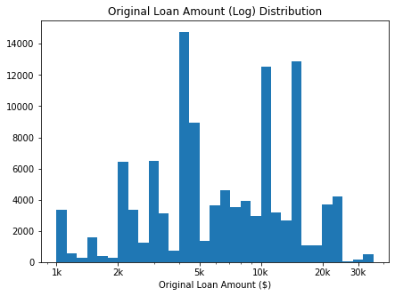

```python
#Histogram to explore the LoanOriginalAmount variable
log_bin = np.log10(loan1['LoanOriginalAmount'])
bins2 = 10**np.arange(3.0, log_bin.max()+0.05, 0.05)
plt.figure(figsize=[7, 5])
plt.hist(data = loan1, x = 'LoanOriginalAmount', bins = bins2)
plt.xscale('log')
plt.xticks([1e3, 2e3, 5e3, 1e4, 2e4, 3e4], ['1k', '2k', '5k', '10k', '20k', '30k'])
plt.xlabel('Original Loan Amount ($)')
plt.title('Original Loan Amount (Log) Distribution')
plt.show()
```

### Correlation Between LoanOriginalAmount, BorrowerRate, StatedMonthlyIncome, and CreditScore

A heat map plotted to show the correlation between LoanOriginalAmount. A positive correlation between LoanOriginal Amount and Stated Monthly Income and Credit Score but a negative correlation between Loan Amount and Borrowers' Interest Rate.

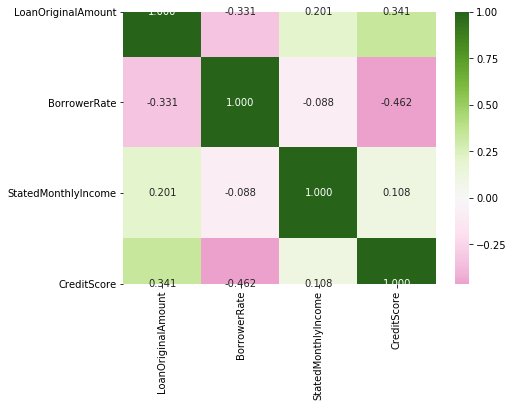

```python
# HeatMap with an annotation of the correlation coefficient of the selected variables
plt.figure(figsize = [7, 5])
sb.heatmap(loan1[num_var].corr(), annot = True, fmt = '.3f', cmap = 'PiYG', center = 0)
plt.show()
```

### OriginalLoanAmount vs BorrowerRate by Loan Term

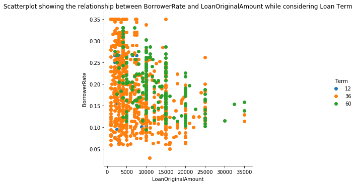

```python
#Select a sample of 1000 for faster rendering and clearer visualization
mydata1_samp2 = loan1.sample(n=1000, replace = False)
#Scatterplot showing the relationship between BorrowerRate and LoanOriginalAmount while considering Loan Term
mult_plt = sb.FacetGrid(data = mydata1_samp2, hue = 'Term', height=5)
mult_plt.map(plt.scatter, 'LoanOriginalAmount', 'BorrowerRate')
mult_plt.add_legend()
plt.title("Scatterplot showing the relationship between BorrowerRate and LoanOriginalAmount while considering Loan Term");
```